# Financial Options: A Monte Carlo Approach

12/7/2021

## Background

- Our project is based on a paper called “Options: A Monte Carlo Approach”
- Written by Phelim P. Boyle in 1977 and published in the Journal of Financial Economics
- Boyle is an Irish economist and a pioneer of quantitative finance
- He is best known for his use of Monte Carlo methods in option pricing

## Financial Terminology

- Stock: security ownership in a particular company
  - ex: common stock of Apple is ~ $165
- Dividend: A sum of money paid regularly by a company to its shareholders
- Inflation Rate: rate at which the value of a currency is falling and the general level of prices for goods and services is rising
- Treasury Yield: yield of a US Treasury Bond matching investment duration
- Risk Free Rate: Represents the interest an investor would expect from a risk-free investment over a specific time
  - RFr = Inflation Rate - Treasury Yield

## The LogNormal Distribution

- Distribution of logarithmic values from a related normal distribution
- Allow for only positive variables whereas the normal distribution can allow for negative variables
- More useful in finance because the log normal curve can better identify the compounding return a stock can achieve over a long period of time

## The LogNormal Distribution

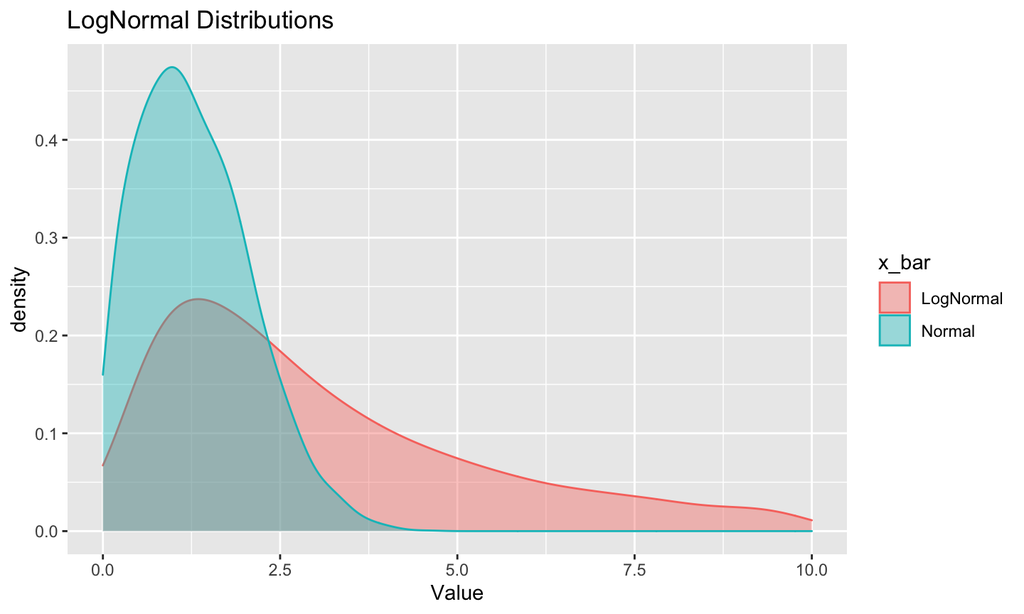

## What are options?

- Options are a very powerful and influential tool used heavily in financial markets
- It is a contract that is valued based on an underlying asset or security like a common stock or bond
  - Derivative, price is linked to price of underlying asset
- Options are more risky than common stock as the price moves faster
- Investors use options for income, to hedge risk and to speculate about future market movements
- When investors sell an underlying stock as an option they receive a premium up front for selling the contract aka the option

## How do options work?

- A single options contract represents 100 shares of the underlying asset it is representing
- Contract gives the buyer the right to buy the underlying asset at a specific price on or by a certain date
- Valuing options is essentially about determining the probabilities of future prices
  - The more likely something is to occur, the more expensive an option for that event
  - The less time to maturity, the less valuable the option
  - Previous to these methods, there was no agreed upon method to determine option prices

## European vs American Options

- There are two types of financial options: European and American
- The main thing to remember between the two, American options can be exercised at any time
- European options can only be exercised at the time of expiration
- Again a Contract gives the buyer the right to buy the underlying asset at a specific price on or by a certain date and exercising the contract just means you finish the translation and buy the stocks.

## Purpose of the Paper

- To show that Monte Carlo simulations provide a method to obtaining numerical solutions to option valuation problems
- Option valuation models are important because large amounts of corporate liabilities can be expressed in terms of options
- Two other methods exist and this method should be used as a supplement
- Boyle’s method is simple and flexible as it can be easily modified for different processes

## Black-Scholes Model

- The Black-Scholes model is the basis for the model from this paper
- Developed in 1973 it is one of the best methods for pricing an option contract
- The paper that we replicated derived their methods from the Black-Scholes Model

C = \(S_t*N(d_1)-K_e^{-rt}*N(d_2)\)

\(d_1 = \frac{ln({S_t/K})+(r+\sigma^2/2)*t}{\sigma_s\sqrt{t}}\)

\(d_2=d_1-\sigma_s*\sqrt{t}\)

## Black-Scholes Model Cont.

- C = call option price
- S = Current underling stock price
- K = Strike price
- r = Risk-free interest rate
- t = Time to maturity
- N = A normal distribution
- This model only prices European options since again American options can be exercised before expiration date causing for more variability.
- This model assumes that variability remains constant.

## Method Overview

- Our Monte Carlo method is used to obtain estimates of option values on dividend paying stocks for European Call options
- Method uses the fact that the distribution of terminal stock prices is determined by the process generating future stock price movements
- This process can then be simulated to generate a series of stock price trajectories
- The series determines a set of terminal stock values which can be used to obtain an estimate of the option value

## Monte Carlo

- \(\int f(y)g(y)\)
- \(\hat{g}\) = MAX[\(S_{T+1}\) - E, 0]
- \(f(y)\) = lognormal distribution
- \(g(y)\) = result we get for final option price
  - random variable because we include \(\tilde{x}\)

## How it works

- \(S_t\) = current stock price at time t
- r = risk free rate per quarter compounded continuously
- \(\sigma^2\) = the (assumed constant) variance rate per quarter on the underlying stock
- \(D_t\) = the dividend payable at time t
- E = exercise price of the option
- Using the properties of the lognormal distribution, we can generate the distribution of stock prices one period hence by forming the random variable,
  - \(S_{t+1} = S_t*exp[r - \sigma^2/2 + \sigma*\tilde{x}]\), \(\tilde{x}\) is \(N(0, 1)\)

## Simulation

- To set up the simulation method in this case, a value of \(S_{t+1}\) is generated
- If \(S_{t+1}\) is greater than \(D_{t+1}\), then (\(S_{t+1}\) - \(D_{t+1}\)) is used as the initial value at the start of the second period
  - The procedure is continued until a value of \(S_T\) is obtained
- If at some stage \(S_{t+m} (m = 1,2,... (T-t-1)\) is less than or equal to the corresponding dividend payment \(D_{t+m}\) the process stops
  - In this case, another simulation trial is started again from time t

## Simulation

- A series of simulation trials is carried out in this way and the expected value of \(MAX[S_T-E, 0]\) is found
  - This quantity is then discounted as the risk-free rate to yield an estimate of the option value \(\hat{g}\)

## Stock Price = $25

| Periods_til_maturity | Option_values | Standard_deviation | lower_95_CI | upper_95_CI |
| --- | --- | --- | --- | --- |
| 2 | 0.0052 | 0.0032 | -0.0012 | 0.0116 |
| 4 | 0.0721 | 0.0145 | 0.0432 | 0.1010 |
| 6 | 0.3293 | 0.0372 | 0.2550 | 0.4037 |
| 8 | 0.6061 | 0.0581 | 0.4899 | 0.7223 |
| 10 | 1.1543 | 0.0887 | 0.9769 | 1.3317 |
| 12 | 1.6322 | 0.1170 | 1.3982 | 1.8662 |
| 14 | 2.3450 | 0.1510 | 2.0430 | 2.6470 |
| 16 | 2.8969 | 0.1823 | 2.5324 | 3.2614 |
| 18 | 3.4185 | 0.2080 | 3.0025 | 3.8346 |

## Stock Price = $25

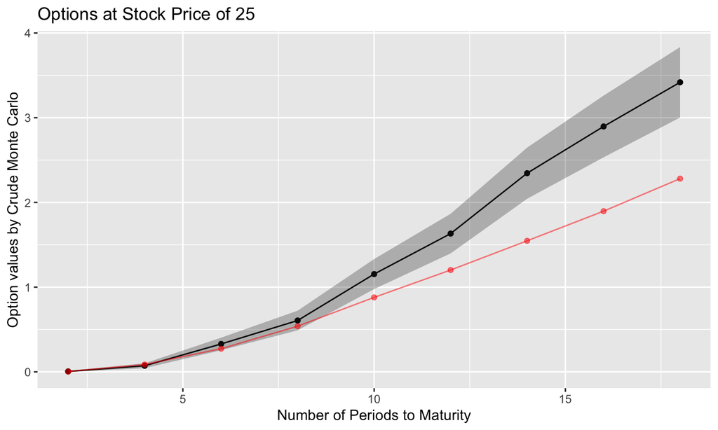

## Stock Price = $50

| Periods_til_maturity | Option_values | Standard_deviation | lower_95_CI | upper_95_CI |
| --- | --- | --- | --- | --- |
| 2 | 5.2420 | 0.1162 | 5.0096 | 5.4745 |
| 4 | 7.8808 | 0.1807 | 7.5194 | 8.2421 |
| 6 | 9.5576 | 0.2318 | 9.0941 | 10.0211 |
| 8 | 12.2239 | 0.2946 | 11.6347 | 12.8131 |
| 10 | 15.8330 | 0.3890 | 15.0551 | 16.6109 |
| 12 | 17.2389 | 0.4345 | 16.3699 | 18.1079 |
| 14 | 19.9847 | 0.5370 | 18.9108 | 21.0587 |
| 16 | 22.5127 | 0.6021 | 21.3084 | 23.7169 |
| 18 | 26.0087 | 0.7172 | 24.5742 | 27.4432 |

## Stock Price = $50

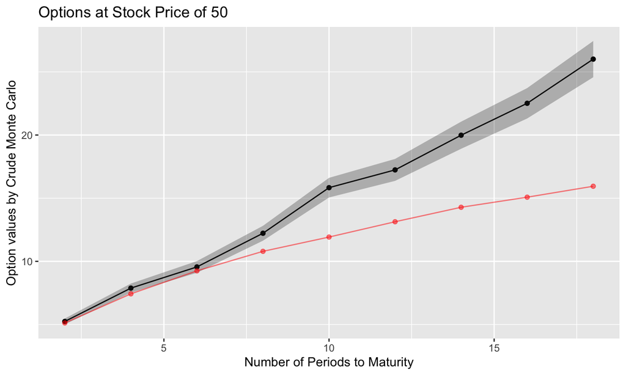

## Stock Price = $75

| Periods_til_maturity | Option_values | Standard_deviation | lower_95_CI | upper_95_CI |
| --- | --- | --- | --- | --- |
| 2 | 27.8347 | 0.2566 | 27.3215 | 28.3479 |
| 4 | 30.4227 | 0.3623 | 29.6981 | 31.1472 |
| 6 | 33.3373 | 0.4612 | 32.4149 | 34.2596 |
| 8 | 35.7313 | 0.5618 | 34.6077 | 36.8548 |
| 10 | 39.3815 | 0.6438 | 38.0939 | 40.6691 |
| 12 | 43.7017 | 0.7641 | 42.1735 | 45.2298 |
| 14 | 48.5979 | 0.9073 | 46.7833 | 50.4125 |
| 16 | 53.5099 | 1.0513 | 51.4074 | 55.6125 |
| 18 | 60.4049 | 1.2368 | 57.9313 | 62.8785 |

## Stock Price = $75

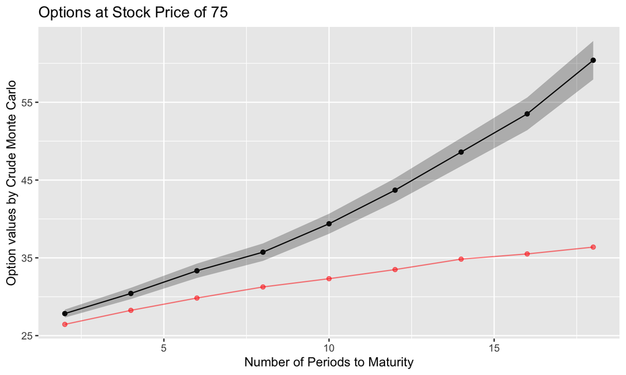

## Questions?

## References

https://www.investopedia.com/options-basics-tutorial-4583012

https://www.investopedia.com/terms/r/risk-freerate.asp

https://www.investopedia.com/terms/b/blackscholes.asp

https://www.in2013dollars.com/UK-inflation-rate-in-1977